# Linear Regression Practice

## Problem Statement

A company want predict their sell based on the amount they are spending on the advertisement on 3 media TV, Radio and Newspaper. So create a model that can help company to increase their sells based on advertisement.

```python
# imports
import numpy as np
import pandas as pd
import seaborn as sns
import random
from sklearn.linear_model import LinearRegression
from sklearn import metrics
from sklearn.model_selection import train_test_split
import warnings
warnings.filterwarnings('ignore')
# allow plots to appear directly in the notebook
%matplotlib inline
```

```python
data = pd.read_csv('Advertising.csv', index_col=0)
data.head()
```

|  | TV | Radio | Newspaper | Sales |
| --- | --- | --- | --- | --- |
| 1 | 230.1 | 37.8 | 69.2 | 22.1 |
| 2 | 44.5 | 39.3 | 45.1 | 10.4 |
| 3 | 17.2 | 45.9 | 69.3 | 9.3 |
| 4 | 151.5 | 41.3 | 58.5 | 18.5 |
| 5 | 180.8 | 10.8 | 58.4 | 12.9 |

```python
# shape of the DataFrame
data.shape
```

```
(200, 4)
```

Here we have 200 data points with 3 features and 1 target.

```python
data.info()
```

```
<class 'pandas.core.frame.DataFrame'>
Int64Index: 200 entries, 1 to 200
Data columns (total 4 columns):
 #   Column     Non-Null Count  Dtype
---  ------     --------------  -----
 0   TV         200 non-null    float64
 1   Radio      200 non-null    float64
 2   Newspaper  200 non-null    float64
 3   Sales      200 non-null    float64
dtypes: float64(4)
memory usage: 7.8 KB
```

all the features are no-null and numeric in nature.

```python
data.describe()
```

|  | TV | Radio | Newspaper | Sales |
| --- | --- | --- | --- | --- |
| count | 200.000000 | 200.000000 | 200.000000 | 200.000000 |
| mean | 147.042500 | 23.264000 | 30.554000 | 14.022500 |
| std | 85.854236 | 14.846809 | 21.778621 | 5.217457 |
| min | 0.700000 | 0.000000 | 0.300000 | 1.600000 |
| 25% | 74.375000 | 9.975000 | 12.750000 | 10.375000 |
| 50% | 149.750000 | 22.900000 | 25.750000 | 12.900000 |
| 75% | 218.825000 | 36.525000 | 45.100000 | 17.400000 |
| max | 296.400000 | 49.600000 | 114.000000 | 27.000000 |

Average spending done on TV advertisements is more that other two.

## EDA

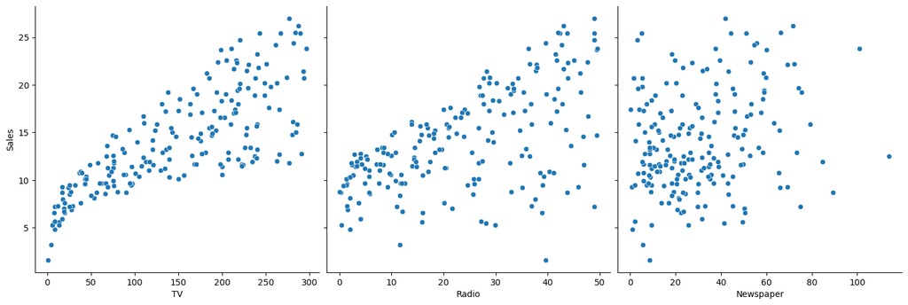

```python
# visualize the relationship between the features and the response using scatterplots
sns.pairplot(data, x_vars=['TV','Radio','Newspaper'], y_vars='Sales', height=5)
```

We could see the Sales is having linear relationsship with TV advertisement. Same is the case with Radio but not that much linear. Sales dont found any linear relationship with newspaper.

```python
import pandas_profiling as pp
```

```python
pp.ProfileReport(data)
```

[interactive chart not shown]

## Build a Model

```python
### SCIKIT-LEARN ###
# Consider one varibale at a time to build a linear regression model.
# Randomised the data and then split the data into train and test

X = data.iloc[:,:2] # here we are not considering Newpaper as it is not having any relationship with target Sales.
Y = data['Sales']

X_train, X_test, Y_train, Y_test = train_test_split(X,Y, train_size=0.8, random_state= 50, shuffle=True)

print (X_train.head())
```

```
        TV  Radio
171   50.0   11.6
184  287.6   43.0
39    43.1   26.7
154  171.3   39.7
41   202.5   22.3
```

```python
# instantiate and fit
lm2 = LinearRegression()
lm2.fit(X_train, Y_train)

# print the coefficients
print(lm2.intercept_)
print(lm2.coef_)
```

```
2.6999542439293034
[0.04704245 0.1888484 ]
```

```python
#Predict the sales for tetst data set
y_predict = lm2.predict(X_test)
```

```python
metrics.r2_score(Y_test,y_predict)
```

```
0.8516296176286774
```

Here R-square value is 0.85 which represents that 85% of Sales variance can be explain by using TV and Radio.

```python
Ex_variance = metrics.explained_variance_score(Y_test,y_predict)
MAR=metrics.mean_absolute_error(Y_test,y_predict)
MSR=metrics.mean_squared_error(Y_test,y_predict)
```

```python
print ("Our Model is having Expalined variance {} \n Mean Absolute Error {} \n Mean Squared Error {}".format(Ex_variance,MAR,MSR))
```

```
Our Model is having Expalined variance 0.8518798198567745
 Mean Absolute Error 1.1148794924799597
 Mean Squared Error 2.1124789579050955
```